# EI-EP06-respuesta-equipo-2

—

2026-04-30

**Un equipo de investigadores del área de interacción humano-información está estudiando si el área temática y el nivel de dificultad del problema de información influyen en el tiempo (en segundos) que toma un usuario en formular una consulta de búsqueda para resolver dicho problema. Para ello, han reclutado a un grupo de participantes voluntarios, asignados aleatoriamente a distintos grupos. Cada participante debe resolver tres problemas de información con diferentes niveles de dificultad: baja, media y alta. A su vez, cada grupo debe resolver problemas relacionados a una temática diferente. Los datos recolectados contemplan las siguientes variables:**

```r
diccionario_variables <- data.frame(
  Variable = c("id","area", "dificultad", "tiempo"),
  Clasificacion = c("Cualitativa nominal",
                    "Cualitativa nominal",
                    "Cualitativa ordinal",
                    "Cuantitativa continua"),
  Descripcion = c(
    "Identificador único de cada participante.",
    "Área temática de los problemas. Niveles: Arquitectura, Biología, Computación, Economía, Física, Leyes, Literatura, Matemáticas, Música, Pedagogía, Psicología, Química.",
    "Nivel de dificultad del problema. Niveles: Baja, Media y Alta.",
    "Tiempo, en segundos, que toma al participante formular la consulta.")
)
kable(diccionario_variables, caption = "Tabla de variables")
```

Tabla de variables

| Variable | Clasificacion | Descripcion |
| --- | --- | --- |
| id | Cualitativa nominal | Identificador único de cada participante. |
| area | Cualitativa nominal | Área temática de los problemas. Niveles: Arquitectura, Biología, Computación, Economía, Física, Leyes, Literatura, Matemáticas, Música, Pedagogía, Psicología, Química. |
| dificultad | Cualitativa ordinal | Nivel de dificultad del problema. Niveles: Baja, Media y Alta. |
| tiempo | Cuantitativa continua | Tiempo, en segundos, que toma al participante formular la consulta. |

# Pregunta 1

**En este momento, los investigadores buscan determinar si existen diferencias en el tiempo que tardan los usuarios en formular consultas para problemas con diferente nivel de dificultad en el área de computación.**

## Carga de datos

```r
datos <- read.csv("EP06 Datos.csv", stringsAsFactors = TRUE)

# Filtrar solo el área de Computación
datos_comp <- datos %>% filter(area == "Computación")

print(table(datos_comp$dificultad))
```

```
##
##  Alta  Baja Media
##   200   200   200
```

## Hipótesis

Ya que cada participante resolvió problemas de 3 niveles de dificultad distintos, se trata de mediciones pareadas (muestras correlacionadas). Por lo tanto se aplicará ANOVA de una vía para muestras correlacionadas (ANOVA de medidas repetidas).

$H_0$: No existen diferencias en el tiempo medio que tardan los participantes del área de Computación en formular consultas según el nivel de dificultad del problema. Matemáticamente: $\mu_{Baja} = \mu_{Media} = \mu_{Alta}$.

$H_A$: Al menos un nivel de dificultad presenta un tiempo medio diferente de los demás. Matemáticamente: $\exists i, j \in \{\text{Baja, Media, Alta}\}, i \neq j \mid \mu_i \neq \mu_j$

Se usará un nivel de significación $\alpha = 0.05$.

## Verificación de condiciones

### 1. Escala de medición

Según la tabla de variables del enunciado se afirma que la variable dependiente (el tiempo) se mide en segundos y el archivo .csv presenta correctamente dicha variable en cada instancia (estudiante), por lo que se cumple la primera condición.

### 2. Independencia de observaciones al interior de la muestra

El enunciado afirma que los estudiantes fueron asignados de forma aleatoria a distintos grupos y asumiendo que cada uno de ellos resolvió individualmente 3 problemas de información, se puede afirmar que se cumple la segunda condición.

### 3. Distribución aproximadamente normal de las diferencias

Para ANOVA de medidas repetidas, se requiere que la distribución de los tiempos en cada condición se aproxime a la normal (o que el tamaño muestral sea suficientemente grande por el TLC).

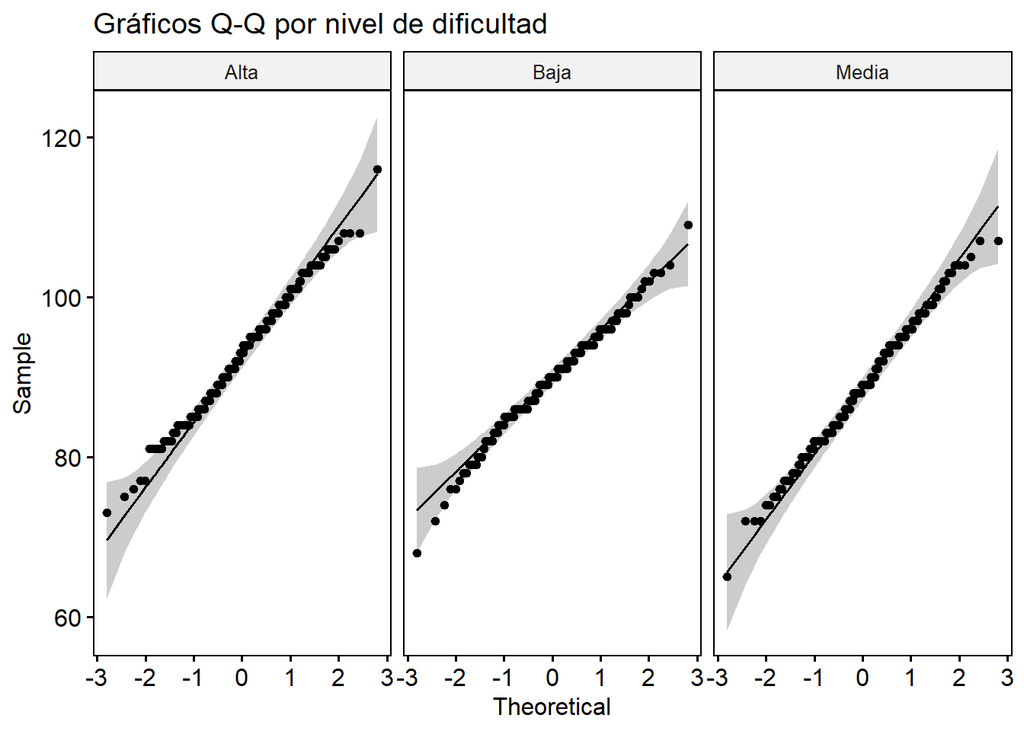

```r
ggqqplot(datos_comp, x = "tiempo", facet.by = "dificultad",
         title = "Gráficos Q-Q por nivel de dificultad")
```

Se utilizó el gráfico Q-Q para evaluar el supuesto de normalidad en cada nivel de dificultad. Se observa que los puntos siguen de cerca la línea de referencia central y se mantienen, en su gran mayoría, dentro de la zona sombreada.

### 4. Esfericidad

La esfericidad se verificará mediante la prueba de Mauchly.

## ANOVA ómnibus de medidas repetidas

```r
datos_comp$id <- factor(datos_comp$id)

modelo_anova <- ezANOVA(
  data      = datos_comp,
  dv        = tiempo,
  wid       = id,
  within    = dificultad,
  detailed  = TRUE,
  type      = 3
)

print(modelo_anova)
```

```
## $ANOVA
##        Effect DFn DFd         SSn      SSd           F             p p<.05
## 1 (Intercept)   1 199 4903476.802 10262.20 95086.04802 1.189420e-268     *
## 2  dificultad   2 398    1857.523 19628.48    18.83219  1.532759e-08     *
##          ges
## 1 0.99394112
## 2 0.05850799
##
## $`Mauchly's Test for Sphericity`
##       Effect        W         p p<.05
## 2 dificultad 0.994467 0.5773603
##
## $`Sphericity Corrections`
##       Effect       GGe       p[GG] p[GG]<.05     HFe        p[HF] p[HF]<.05
## 2 dificultad 0.9944974 1.66024e-08         * 1.00451 1.532759e-08         *
```

Con lo anterior se cumple el supuesto de esfericidad (Mauchly, $W = 0.994, p = 0.577$).

Por lo tanto, se rechaza la hipótesis nula.

## Análisis post-hoc

Ahora se hará un análisis post-hoc para identificar “qué pares” de niveles difieren. Se usará la corrección de Bonferroni para comparaciones múltiples con muestras correlacionadas.

```r
modelo_aov <- aov(tiempo ~ dificultad + Error(id/dificultad), data = datos_comp)

emm <- emmeans(modelo_aov, ~ dificultad)
```

```
## Note: re-fitting model with sum-to-zero contrasts
```

```r
comparaciones <- pairs(emm, adjust = "bonferroni")
print(comparaciones)
```

```
##  contrast     estimate    SE  df t.ratio p.value
##  Alta - Baja      3.12 0.702 398   4.443 <0.0001
##  Alta - Media     4.13 0.702 398   5.888 <0.0001
##  Baja - Media     1.01 0.702 398   1.445  0.4475
##
## P value adjustment: bonferroni method for 3 tests
```

```r
print(summary(emm))
```

```
##  dificultad emmean  SE  df lower.CL upper.CL
##  Alta         92.8 0.5 597     91.8     93.8
##  Baja         89.7 0.5 597     88.7     90.7
##  Media        88.7 0.5 597     87.7     89.7
##
## Warning: EMMs are biased unless design is perfectly balanced
## Confidence level used: 0.95
```

## Conclusión

El análisis post-hoc con corrección de Bonferroni revela que la diferencia detectada por el ANOVA se debe principalmente al nivel de dificultad Alta, el cual requiere un tiempo de formulación significativamente mayor (92.8 s) en comparación con el nivel Bajo (89.7 s) y Medio (88.7 s), con un $p < 0.001$ en ambos casos.

# Pregunta 2

**Propongan una pregunta de investigación relacionada al uso de diferentes entornos de desarrollo integrado (IDE) que necesite ser analizado por medio de un procedimiento ANOVA para muestras correlacionadas con un factor que tenga entre 4 y 6 niveles. Luego invente una población para cada grupo con 5.000 datos, asegurando que cumpla las suposiciones de esta prueba.**

Pregunta de investigación: ¿Existen diferencias en el tiempo (en minutos) que tarda un desarrollador en encontrar y corregir un error de lógica (bug) utilizando las herramientas de depuración integradas de diferentes IDEs?

Factor (4 niveles): VS Code, Eclipse, IntelliJ IDEA, PyCharm

Variable Dependiente: Tiempo transcurrido desde la ejecución del programa hasta la corrección del bug.

```r
set.seed(13)
n_desarrollador <- 5000
ides <- c("VS Code", "IntelliJ IDEA", "PyCharm", "Eclipse")
medias_ide <- c(18.5, 22.0, 21.0, 28.5)

# Aseguramos esferidad
matriz_cov <- matrix(10, nrow = 4, ncol = 4)
diag(matriz_cov) <- 25

# Aseguramos normalidad
datos_anchos <- as.data.frame(mvrnorm(n = n_desarrollador,
                                      mu    = medias_ide,
                                      Sigma = matriz_cov))
colnames(datos_anchos) <- ides
datos_anchos <- cbind(id = 1:n_desarrollador, datos_anchos)

# Observaciones individuales
poblacion_ide <- datos_anchos %>%
  pivot_longer(cols = all_of(ides),
               names_to  = "IDE",
               values_to = "tiempo_debug") %>%
  mutate(id  = factor(id),
         IDE = factor(IDE, levels = ides))
```

Los datos fueron creados con la intención de que ya cumplan con los requisitos de ANOVA.

Independencia: Se cumple porque la simulación crea a cada uno de los 5.000 desarrolladores como una persona separada que no se afectan entre si.

Muestras Correlacionadas: Al usar una matriz de covarianza, los tiempos de cada desarrollador para los 4 IDEs no son independientes.

Normalidad: La función “mvrnorm” extrae datos directamente de una distribución Normal Multivariada. Esto asegura que cada grupo siga una campana de Gauss perfecta, cumpliendo el requisito de normalidad.

Esfericidad: Se cumple porque diseñamos una relación idéntica entre todos los IDEs dejando la misma varianza para cada IDEs.

```r
# Resumen
resumen <- poblacion_ide %>%
  group_by(IDE) %>%
  summarise(
    N     = n(),
    Media = round(mean(tiempo_debug), 2),
    DE    = round(sd(tiempo_debug),   2),
    Min   = round(min(tiempo_debug),  2),
    Max   = round(max(tiempo_debug),  2)
  )
kable(resumen, caption = "Resumen de las IDEs")
```

Resumen de las IDEs

| IDE | N | Media | DE | Min | Max |
| --- | --- | --- | --- | --- | --- |
| VS Code | 5000 | 18.51 | 5.02 | 1.06 | 38.32 |
| IntelliJ IDEA | 5000 | 22.06 | 4.97 | -0.51 | 39.11 |
| PyCharm | 5000 | 21.06 | 5.05 | 3.01 | 38.71 |
| Eclipse | 5000 | 28.41 | 5.05 | 10.76 | 45.08 |

Los datos muestran una clara diferencia en el rendimiento entre herramientas. VS Code presenta el tiempo de depuración más bajo (18.5 min), poniendose como la herramienta más rápida en esta prueba, mientras que Eclipse muestra el tiempo más elevado (28.4 min), lo que sugiere una mayor carga cognitiva o complejidad en su interfaz de depuración.

Aplicamos ahora la prueba ezANOVA para muestras correlacionadas.

```r
# Prueba Ómnibus
anova_resultados <- ezANOVA(
  data = poblacion_ide,
  dv = tiempo_debug,
  wid = id,
  within = IDE,
  type = 3,
  detailed = TRUE
)

print(anova_resultados)
```

```
## $ANOVA
##        Effect DFn   DFd      SSn      SSd          F p p<.05       ges
## 1 (Intercept)   1  4999 10133829 276397.5 183283.171 0     * 0.9526384
## 2         IDE   3 14997   265511 227418.3   5836.336 0     * 0.3451212
##
## $`Mauchly's Test for Sphericity`
##   Effect         W         p p<.05
## 2    IDE 0.9987889 0.3007702
##
## $`Sphericity Corrections`
##   Effect       GGe p[GG] p[GG]<.05      HFe p[HF] p[HF]<.05
## 2    IDE 0.9991869     0         * 0.999853     0         *
```

Dado que la prueba ómnibus resultó significativa y el factor (IDE) cuenta con cuatro niveles, corresponde realizar un análisis post-hoc para identificar exactamente entre qué entornos de desarrollo existen estas diferencias.

```r
# Análisis con Post-Hoc
post_hoc <- pairwise.t.test(
  x = poblacion_ide$tiempo_debug,
  g = poblacion_ide$IDE,
  paired = TRUE,                  # TRUE, ya que son muestras correlacionadas
  p.adjust.method = "holm"
)

# Ver los resultados
print(post_hoc)
```

```
##
##  Pairwise comparisons using paired t tests
##
## data:  poblacion_ide$tiempo_debug and poblacion_ide$IDE
##
##               VS Code IntelliJ IDEA PyCharm
## IntelliJ IDEA <2e-16  -             -
## PyCharm       <2e-16  <2e-16        -
## Eclipse       <2e-16  <2e-16        <2e-16
##
## P value adjustment method: holm
```

Se llevaron a cabo varias pruebas T apareadas, en cada caso se controló la tasa de error familiar (Family-wise error rate) mediante el método de corrección de Holm. La matriz de resultados indica que todas las comparaciones por pares fueron significativas estadísticamente (p < 0.001 en todos los casos). Esto muestra que el tiempo de depuración no solamente difiere entre el IDE más rápido con el más lento, sino que cada herramienta tiene un rendimiento singular y diferenciable del resto.

# Conclusion

Se puede concluir que el estilo de IDE tiene un impacto significativo en periódicos de que los desarrolladores se toman para localizar y corregir un error lógico.